# Optimal Treatment Analysis

## Outcome Variable

**Outcome Variable:** whz

## Predictor Variables

**Intervention Variable:** perdiar6

**Adjustment Set:**

- arm
- sex
- W_mage
- meducyrs
- feducyrs
- hhwealth_quart
- hfoodsec
- W_mhtcm
- W_mwtkg
- W_mbmi
- W_birthwt
- W_birthlen
- W_nrooms
- month
- brthmon
- impfloor
- impsan
- safeh20
- delta_W_mage
- delta_meducyrs
- delta_feducyrs
- delta_hhwealth_quart
- delta_hfoodsec
- delta_W_mhtcm
- delta_W_mwtkg
- delta_W_mbmi
- delta_W_birthwt
- delta_W_birthlen
- delta_W_nrooms
- delta_month
- delta_brthmon
- delta_impfloor
- delta_impsan
- delta_safeh20

## Stratifying Variables

The analysis was stratified on these variable(s):

- agecat
- studyid
- country

## Data Summary

| agecat | studyid | country | perdiar6 | n_cell | n |
| --- | --- | --- | --- | --- | --- |
| Birth | ki0047075b-MAL-ED | BANGLADESH | 0% | 65 | 215 |
| Birth | ki0047075b-MAL-ED | BANGLADESH | (0%, 5%] | 86 | 215 |
| Birth | ki0047075b-MAL-ED | BANGLADESH | >5% | 64 | 215 |
| Birth | ki0047075b-MAL-ED | BRAZIL | 0% | 54 | 62 |
| Birth | ki0047075b-MAL-ED | BRAZIL | (0%, 5%] | 6 | 62 |
| Birth | ki0047075b-MAL-ED | BRAZIL | >5% | 2 | 62 |
| Birth | ki0047075b-MAL-ED | INDIA | 0% | 11 | 45 |
| Birth | ki0047075b-MAL-ED | INDIA | (0%, 5%] | 23 | 45 |
| Birth | ki0047075b-MAL-ED | INDIA | >5% | 11 | 45 |
| Birth | ki0047075b-MAL-ED | NEPAL | 0% | 8 | 26 |
| Birth | ki0047075b-MAL-ED | NEPAL | (0%, 5%] | 10 | 26 |
| Birth | ki0047075b-MAL-ED | NEPAL | >5% | 8 | 26 |
| Birth | ki0047075b-MAL-ED | PERU | 0% | 67 | 228 |
| Birth | ki0047075b-MAL-ED | PERU | (0%, 5%] | 69 | 228 |
| Birth | ki0047075b-MAL-ED | PERU | >5% | 92 | 228 |
| Birth | ki0047075b-MAL-ED | SOUTH AFRICA | 0% | 85 | 112 |
| Birth | ki0047075b-MAL-ED | SOUTH AFRICA | (0%, 5%] | 23 | 112 |
| Birth | ki0047075b-MAL-ED | SOUTH AFRICA | >5% | 4 | 112 |
| Birth | ki0047075b-MAL-ED | TANZANIA, UNITED REPUBLIC OF | 0% | 51 | 115 |
| Birth | ki0047075b-MAL-ED | TANZANIA, UNITED REPUBLIC OF | (0%, 5%] | 44 | 115 |
| Birth | ki0047075b-MAL-ED | TANZANIA, UNITED REPUBLIC OF | >5% | 20 | 115 |
| Birth | ki1000109-EE | PAKISTAN | 0% | 164 | 177 |
| Birth | ki1000109-EE | PAKISTAN | (0%, 5%] | 11 | 177 |
| Birth | ki1000109-EE | PAKISTAN | >5% | 2 | 177 |
| Birth | ki1017093-NIH-Birth | BANGLADESH | 0% | 150 | 572 |
| Birth | ki1017093-NIH-Birth | BANGLADESH | (0%, 5%] | 171 | 572 |
| Birth | ki1017093-NIH-Birth | BANGLADESH | >5% | 251 | 572 |
| Birth | ki1017093b-PROVIDE | BANGLADESH | 0% | 160 | 532 |
| Birth | ki1017093b-PROVIDE | BANGLADESH | (0%, 5%] | 206 | 532 |
| Birth | ki1017093b-PROVIDE | BANGLADESH | >5% | 166 | 532 |

[output cut: 87 more lines]

The following strata were considered:

- agecat: 24 months, studyid: ki0047075b-MAL-ED, country: BANGLADESH
- agecat: 24 months, studyid: ki0047075b-MAL-ED, country: BRAZIL
- agecat: 24 months, studyid: ki0047075b-MAL-ED, country: INDIA
- agecat: 24 months, studyid: ki0047075b-MAL-ED, country: NEPAL
- agecat: 24 months, studyid: ki0047075b-MAL-ED, country: PERU
- agecat: 24 months, studyid: ki0047075b-MAL-ED, country: SOUTH AFRICA
- agecat: 24 months, studyid: ki0047075b-MAL-ED, country: TANZANIA, UNITED REPUBLIC OF
- agecat: 24 months, studyid: ki1000109-EE, country: PAKISTAN
- agecat: 24 months, studyid: ki1017093-NIH-Birth, country: BANGLADESH
- agecat: 24 months, studyid: ki1017093b-PROVIDE, country: BANGLADESH
- agecat: 24 months, studyid: ki1017093c-NIH-Crypto, country: BANGLADESH
- agecat: 24 months, studyid: ki1114097-CMIN, country: BANGLADESH
- agecat: 24 months, studyid: ki1114097-CONTENT, country: PERU
- agecat: 6 months, studyid: ki0047075b-MAL-ED, country: BANGLADESH
- agecat: 6 months, studyid: ki0047075b-MAL-ED, country: BRAZIL
- agecat: 6 months, studyid: ki0047075b-MAL-ED, country: INDIA
- agecat: 6 months, studyid: ki0047075b-MAL-ED, country: NEPAL
- agecat: 6 months, studyid: ki0047075b-MAL-ED, country: PERU
- agecat: 6 months, studyid: ki0047075b-MAL-ED, country: SOUTH AFRICA
- agecat: 6 months, studyid: ki0047075b-MAL-ED, country: TANZANIA, UNITED REPUBLIC OF
- agecat: 6 months, studyid: ki1000109-EE, country: PAKISTAN
- agecat: 6 months, studyid: ki1017093-NIH-Birth, country: BANGLADESH
- agecat: 6 months, studyid: ki1017093b-PROVIDE, country: BANGLADESH
- agecat: 6 months, studyid: ki1017093c-NIH-Crypto, country: BANGLADESH
- agecat: 6 months, studyid: ki1114097-CMIN, country: BANGLADESH
- agecat: 6 months, studyid: ki1114097-CONTENT, country: PERU
- agecat: Birth, studyid: ki0047075b-MAL-ED, country: BANGLADESH
- agecat: Birth, studyid: ki0047075b-MAL-ED, country: BRAZIL
- agecat: Birth, studyid: ki0047075b-MAL-ED, country: INDIA
- agecat: Birth, studyid: ki0047075b-MAL-ED, country: NEPAL
- agecat: Birth, studyid: ki0047075b-MAL-ED, country: PERU
- agecat: Birth, studyid: ki0047075b-MAL-ED, country: SOUTH AFRICA
- agecat: Birth, studyid: ki0047075b-MAL-ED, country: TANZANIA, UNITED REPUBLIC OF
- agecat: Birth, studyid: ki1000109-EE, country: PAKISTAN
- agecat: Birth, studyid: ki1017093-NIH-Birth, country: BANGLADESH
- agecat: Birth, studyid: ki1017093b-PROVIDE, country: BANGLADESH
- agecat: Birth, studyid: ki1017093c-NIH-Crypto, country: BANGLADESH
- agecat: Birth, studyid: ki1114097-CMIN, country: BANGLADESH
- agecat: Birth, studyid: ki1114097-CONTENT, country: PERU

### Dropped Strata

Some strata were dropped due to rare outcomes:

- agecat: Birth, studyid: ki0047075b-MAL-ED, country: BRAZIL
- agecat: Birth, studyid: ki0047075b-MAL-ED, country: SOUTH AFRICA
- agecat: Birth, studyid: ki1000109-EE, country: PAKISTAN
- agecat: Birth, studyid: ki1114097-CMIN, country: BANGLADESH
- agecat: Birth, studyid: ki1114097-CONTENT, country: PERU
- agecat: 6 months, studyid: ki0047075b-MAL-ED, country: BRAZIL
- agecat: 6 months, studyid: ki1000109-EE, country: PAKISTAN
- agecat: 24 months, studyid: ki0047075b-MAL-ED, country: BRAZIL
- agecat: 24 months, studyid: ki1000109-EE, country: PAKISTAN

## Methods Detail

We’re interested in the causal parameters $E[Y_a]$ for all values of $a \in \mathcal{A}$. These parameters represent the mean outcome if, possibly contrary to fact, we intervened to set all units to have $A=a$. Under the randomization and positivity assumptions, these are identified by the statistical parameters $\psi_a=E_W[E_{Y|A,W}(Y|A=a,W)]$. In addition, we’re interested in the mean of $Y$, $E[Y]$ under no intervention (the observed mean). We will estimate these parameters by using SuperLearner to fit the relevant likelihood factors – $E_{Y|A,W}(Y|A=a,W)$ and $p(A=a|W)$, and then updating our likelihood fit using a joint TMLE.

For unadjusted analyses ($W=\{\}$), initial likelihoods were estimated using Lrnr_glm to estimate the simple $E(Y|A)$ and Lrnr_mean to estimate $p(A)$. For adjusted analyses, a small library containing Lrnr_glmnet, Lrnr_xgboost, and Lrnr_mean was used.

Having estimated these parameters, we will then use the delta method to estimate relative risks and attributable risks relative to a prespecified baseline level of $A$.

# Results Detail

## Results Plots

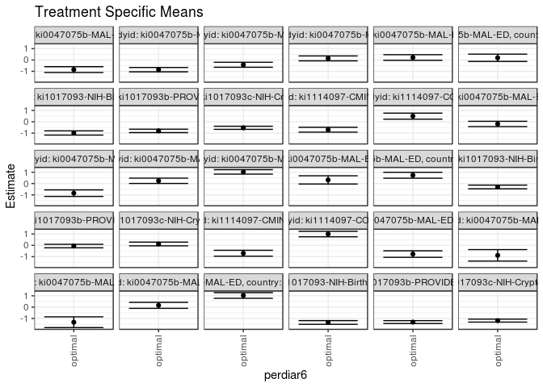

## Results Table

### Parameter: TSM

| agecat | studyid | country | intervention_level | baseline_level | estimate | ci_lower | ci_upper |
| --- | --- | --- | --- | --- | --- | --- | --- |
| Birth | ki0047075b-MAL-ED | BANGLADESH | optimal | observed | -0.7685320 | -1.0563755 | -0.4806885 |
| Birth | ki0047075b-MAL-ED | INDIA | optimal | observed | -0.8813050 | -1.3886832 | -0.3739267 |
| Birth | ki0047075b-MAL-ED | NEPAL | optimal | observed | -1.3288076 | -1.8036632 | -0.8539519 |
| Birth | ki0047075b-MAL-ED | PERU | optimal | observed | 0.1586727 | -0.1051439 | 0.4224893 |
| Birth | ki0047075b-MAL-ED | TANZANIA, UNITED REPUBLIC OF | optimal | observed | 1.0277042 | 0.7790417 | 1.2763668 |
| Birth | ki1017093-NIH-Birth | BANGLADESH | optimal | observed | -1.3522469 | -1.5149233 | -1.1895706 |
| Birth | ki1017093b-PROVIDE | BANGLADESH | optimal | observed | -1.3201192 | -1.4478578 | -1.1923806 |
| Birth | ki1017093c-NIH-Crypto | BANGLADESH | optimal | observed | -1.1891237 | -1.3189163 | -1.0593312 |
| 6 months | ki0047075b-MAL-ED | BANGLADESH | optimal | observed | -0.1912029 | -0.4269892 | 0.0445835 |
| 6 months | ki0047075b-MAL-ED | INDIA | optimal | observed | -0.8467731 | -1.1342647 | -0.5592814 |
| 6 months | ki0047075b-MAL-ED | NEPAL | optimal | observed | 0.2427574 | 0.0070664 | 0.4784485 |
| 6 months | ki0047075b-MAL-ED | PERU | optimal | observed | 1.0284247 | 0.8334837 | 1.2233657 |
| 6 months | ki0047075b-MAL-ED | SOUTH AFRICA | optimal | observed | 0.3224519 | -0.0409044 | 0.6858083 |
| 6 months | ki0047075b-MAL-ED | TANZANIA, UNITED REPUBLIC OF | optimal | observed | 0.7336157 | 0.4725291 | 0.9947022 |
| 6 months | ki1017093-NIH-Birth | BANGLADESH | optimal | observed | -0.3007534 | -0.4645151 | -0.1369917 |
| 6 months | ki1017093b-PROVIDE | BANGLADESH | optimal | observed | -0.0629542 | -0.2167166 | 0.0908082 |
| 6 months | ki1017093c-NIH-Crypto | BANGLADESH | optimal | observed | 0.1215872 | -0.0430575 | 0.2862319 |
| 6 months | ki1114097-CMIN | BANGLADESH | optimal | observed | -0.6971417 | -0.9580706 | -0.4362128 |
| 6 months | ki1114097-CONTENT | PERU | optimal | observed | 0.9978118 | 0.7544819 | 1.2411418 |
| 24 months | ki0047075b-MAL-ED | BANGLADESH | optimal | observed | -0.8467150 | -1.1021773 | -0.5912526 |
| 24 months | ki0047075b-MAL-ED | INDIA | optimal | observed | -0.8508717 | -1.0420574 | -0.6596860 |
| 24 months | ki0047075b-MAL-ED | NEPAL | optimal | observed | -0.4195356 | -0.6398013 | -0.1992700 |
| 24 months | ki0047075b-MAL-ED | PERU | optimal | observed | 0.1422585 | -0.0757484 | 0.3602654 |
| 24 months | ki0047075b-MAL-ED | SOUTH AFRICA | optimal | observed | 0.2201882 | -0.0269308 | 0.4673071 |
| 24 months | ki0047075b-MAL-ED | TANZANIA, UNITED REPUBLIC OF | optimal | observed | 0.1943034 | -0.1273064 | 0.5159132 |
| 24 months | ki1017093-NIH-Birth | BANGLADESH | optimal | observed | -0.9871238 | -1.1729715 | -0.8012760 |
| 24 months | ki1017093b-PROVIDE | BANGLADESH | optimal | observed | -0.8032637 | -0.9541486 | -0.6523787 |
| 24 months | ki1017093c-NIH-Crypto | BANGLADESH | optimal | observed | -0.5306866 | -0.6675515 | -0.3938216 |
| 24 months | ki1114097-CMIN | BANGLADESH | optimal | observed | -0.7000011 | -0.9141817 | -0.4858206 |
| 24 months | ki1114097-CONTENT | PERU | optimal | observed | 0.4955777 | 0.2294836 | 0.7616718 |

### Parameter: E(Y)

| agecat | studyid | country | intervention_level | baseline_level | estimate | ci_lower | ci_upper |
| --- | --- | --- | --- | --- | --- | --- | --- |
| Birth | ki0047075b-MAL-ED | BANGLADESH | observed | observed | -0.9412093 | -1.0864308 | -0.7959878 |
| Birth | ki0047075b-MAL-ED | INDIA | observed | observed | -0.9324444 | -1.2067907 | -0.6580982 |
| Birth | ki0047075b-MAL-ED | NEPAL | observed | observed | -0.7684615 | -1.1257770 | -0.4111460 |
| Birth | ki0047075b-MAL-ED | PERU | observed | observed | -0.0520175 | -0.1725298 | 0.0684947 |
| Birth | ki0047075b-MAL-ED | TANZANIA, UNITED REPUBLIC OF | observed | observed | 0.7624348 | 0.5710709 | 0.9537986 |
| Birth | ki1017093-NIH-Birth | BANGLADESH | observed | observed | -1.3525437 | -1.4473932 | -1.2576942 |
| Birth | ki1017093b-PROVIDE | BANGLADESH | observed | observed | -1.2984586 | -1.3752758 | -1.2216415 |
| Birth | ki1017093c-NIH-Crypto | BANGLADESH | observed | observed | -1.2441513 | -1.3281130 | -1.1601897 |
| 6 months | ki0047075b-MAL-ED | BANGLADESH | observed | observed | -0.1383956 | -0.2672708 | -0.0095204 |
| 6 months | ki0047075b-MAL-ED | INDIA | observed | observed | -0.7082698 | -0.8347304 | -0.5818092 |
| 6 months | ki0047075b-MAL-ED | NEPAL | observed | observed | 0.1110452 | -0.0202712 | 0.2423616 |
| 6 months | ki0047075b-MAL-ED | PERU | observed | observed | 1.0568987 | 0.9352990 | 1.1784983 |
| 6 months | ki0047075b-MAL-ED | SOUTH AFRICA | observed | observed | 0.5427231 | 0.3906363 | 0.6948099 |
| 6 months | ki0047075b-MAL-ED | TANZANIA, UNITED REPUBLIC OF | observed | observed | 0.5362213 | 0.4049390 | 0.6675036 |
| 6 months | ki1017093-NIH-Birth | BANGLADESH | observed | observed | -0.4474038 | -0.5378167 | -0.3569909 |
| 6 months | ki1017093b-PROVIDE | BANGLADESH | observed | observed | -0.1990907 | -0.2817968 | -0.1163845 |
| 6 months | ki1017093c-NIH-Crypto | BANGLADESH | observed | observed | 0.0297622 | -0.0491685 | 0.1086930 |
| 6 months | ki1114097-CMIN | BANGLADESH | observed | observed | -0.5780453 | -0.7226627 | -0.4334279 |
| 6 months | ki1114097-CONTENT | PERU | observed | observed | 1.0684318 | 0.9515274 | 1.1853362 |
| 24 months | ki0047075b-MAL-ED | BANGLADESH | observed | observed | -0.8201887 | -0.9423967 | -0.6979806 |
| 24 months | ki0047075b-MAL-ED | INDIA | observed | observed | -0.9522907 | -1.0676596 | -0.8369219 |
| 24 months | ki0047075b-MAL-ED | NEPAL | observed | observed | -0.3764474 | -0.4898516 | -0.2630431 |
| 24 months | ki0047075b-MAL-ED | PERU | observed | observed | 0.1204478 | 0.0005049 | 0.2403906 |
| 24 months | ki0047075b-MAL-ED | SOUTH AFRICA | observed | observed | 0.4148529 | 0.2940577 | 0.5356481 |
| 24 months | ki0047075b-MAL-ED | TANZANIA, UNITED REPUBLIC OF | observed | observed | 0.0539486 | -0.0712465 | 0.1791437 |
| 24 months | ki1017093-NIH-Birth | BANGLADESH | observed | observed | -0.9115790 | -1.0095022 | -0.8136559 |
| 24 months | ki1017093b-PROVIDE | BANGLADESH | observed | observed | -0.8928670 | -0.9755153 | -0.8102187 |
| 24 months | ki1017093c-NIH-Crypto | BANGLADESH | observed | observed | -0.6103502 | -0.7050157 | -0.5156847 |
| 24 months | ki1114097-CMIN | BANGLADESH | observed | observed | -0.8535391 | -0.9644236 | -0.7426546 |
| 24 months | ki1114097-CONTENT | PERU | observed | observed | 0.5668293 | 0.4302437 | 0.7034148 |

### Parameter: PAR

| agecat | studyid | country | intervention_level | baseline_level | estimate | ci_lower | ci_upper |
| --- | --- | --- | --- | --- | --- | --- | --- |
| Birth | ki0047075b-MAL-ED | BANGLADESH | optimal | observed | -0.1726773 | -0.4069940 | 0.0616394 |
| Birth | ki0047075b-MAL-ED | INDIA | optimal | observed | -0.0511395 | -0.5173814 | 0.4151025 |
| Birth | ki0047075b-MAL-ED | NEPAL | optimal | observed | 0.5603460 | 0.1114067 | 1.0092853 |
| Birth | ki0047075b-MAL-ED | PERU | optimal | observed | -0.2106903 | -0.4315771 | 0.0101966 |
| Birth | ki0047075b-MAL-ED | TANZANIA, UNITED REPUBLIC OF | optimal | observed | -0.2652694 | -0.4759518 | -0.0545871 |
| Birth | ki1017093-NIH-Birth | BANGLADESH | optimal | observed | -0.0002968 | -0.1411584 | 0.1405648 |
| Birth | ki1017093b-PROVIDE | BANGLADESH | optimal | observed | 0.0216606 | -0.0860584 | 0.1293795 |
| Birth | ki1017093c-NIH-Crypto | BANGLADESH | optimal | observed | -0.0550276 | -0.1633021 | 0.0532469 |
| 6 months | ki0047075b-MAL-ED | BANGLADESH | optimal | observed | 0.0528073 | -0.1455512 | 0.2511658 |
| 6 months | ki0047075b-MAL-ED | INDIA | optimal | observed | 0.1385033 | -0.0940931 | 0.3710998 |
| 6 months | ki0047075b-MAL-ED | NEPAL | optimal | observed | -0.1317122 | -0.3205322 | 0.0571077 |
| 6 months | ki0047075b-MAL-ED | PERU | optimal | observed | 0.0284740 | -0.1196801 | 0.1766281 |
| 6 months | ki0047075b-MAL-ED | SOUTH AFRICA | optimal | observed | 0.2202712 | -0.1549211 | 0.5954635 |
| 6 months | ki0047075b-MAL-ED | TANZANIA, UNITED REPUBLIC OF | optimal | observed | -0.1973943 | -0.4381605 | 0.0433718 |
| 6 months | ki1017093-NIH-Birth | BANGLADESH | optimal | observed | -0.1466504 | -0.2842635 | -0.0090373 |
| 6 months | ki1017093b-PROVIDE | BANGLADESH | optimal | observed | -0.1361365 | -0.2580761 | -0.0141969 |
| 6 months | ki1017093c-NIH-Crypto | BANGLADESH | optimal | observed | -0.0918250 | -0.2292671 | 0.0456172 |
| 6 months | ki1114097-CMIN | BANGLADESH | optimal | observed | 0.1190964 | -0.1044093 | 0.3426021 |
| 6 months | ki1114097-CONTENT | PERU | optimal | observed | 0.0706200 | -0.1472446 | 0.2884846 |
| 24 months | ki0047075b-MAL-ED | BANGLADESH | optimal | observed | 0.0265263 | -0.1771741 | 0.2302267 |
| 24 months | ki0047075b-MAL-ED | INDIA | optimal | observed | -0.1014190 | -0.2572113 | 0.0543733 |
| 24 months | ki0047075b-MAL-ED | NEPAL | optimal | observed | 0.0430883 | -0.1285161 | 0.2146927 |
| 24 months | ki0047075b-MAL-ED | PERU | optimal | observed | -0.0218108 | -0.1781374 | 0.1345158 |
| 24 months | ki0047075b-MAL-ED | SOUTH AFRICA | optimal | observed | 0.1946648 | -0.0155104 | 0.4048400 |
| 24 months | ki0047075b-MAL-ED | TANZANIA, UNITED REPUBLIC OF | optimal | observed | -0.1403548 | -0.4245223 | 0.1438127 |
| 24 months | ki1017093-NIH-Birth | BANGLADESH | optimal | observed | 0.0755447 | -0.0816744 | 0.2327638 |
| 24 months | ki1017093b-PROVIDE | BANGLADESH | optimal | observed | -0.0896034 | -0.2076271 | 0.0284204 |
| 24 months | ki1017093c-NIH-Crypto | BANGLADESH | optimal | observed | -0.0796636 | -0.1646140 | 0.0052867 |
| 24 months | ki1114097-CMIN | BANGLADESH | optimal | observed | -0.1535380 | -0.3470819 | 0.0400060 |
| 24 months | ki1114097-CONTENT | PERU | optimal | observed | 0.0712516 | -0.1695110 | 0.3120142 |